# Most Harmful Weather Events

Sarthak Dasadia

9/26/2016

## Synopsis

Storms and other severe weather events can cause both public health and economic problems for communities and municipalities. Many severe events can result in fatalities, injuries, and property damage, and preventing such outcomes to the extent possible is a key concern.

This report explore the U.S. National Oceanic and Atmospheric Administration’s (NOAA) storm database and answer the following questions:

Across the United States, which types of events (as indicated in the Event variable) are most harmful with respect to population health?

Across the United States, which types of events have the greatest economic consequences?

## Data

The data for this assignment come in the form of a comma-separated-value file compressed via the bzip2 algorithm to reduce its size. You can download the file from the course web site

- [Storm Data (47 MB)](https://d396qusza40orc.cloudfront.net/repdata%2Fdata%2FStormData.csv.bz2)

There is also some documentation of the database available.You will find how some of the variables are constructed/defined.

- [Documentation](https://d396qusza40orc.cloudfront.net/repdata%2Fpeer2_doc%2Fpd01016005curr.pdf)

The events in the database start in the year 1950 and end in November 2011. In the earlier years of the database there are generally fewer events recorded, most likely due to a lack of good records. More recent years should be considered more complete.

## Data Processing

- Let’s start by downloading and reading the file containing raw data

```r
setwd("~/Desktop")
data <- read.csv("repdata-data-StormData.csv")
```

- Filter required columns

```r
red.data <- data[,c("EVTYPE","FATALITIES", "INJURIES", "PROPDMG")]
```

- Change the Event type Names

```r
red.data$EVTYPE <- gsub("^HEAT$", "EXCESSIVE HEAT", red.data$EVTYPE)
red.data$EVTYPE <- gsub("^TSTM WIND$", "THUNDERSTORM WIND", red.data$EVTYPE)
red.data$EVTYPE <- gsub("^THUNDERSTORM WIND$", "THUNDERSTORM WINDS", red.data$EVTYPE)
```

- Aggregated Data

```r
fatalities.data <- aggregate(red.data$FATALITIES, by=list(red.data$EVTYPE), FUN=sum, na.rm=TRUE)
colnames(fatalities.data) = c("event.type", "fatality.total")
```

- Events with highest Fatalities

```r
fatalities.sorted <- fatalities.data[order(-fatalities.data$fatality.total),]
top.fatalities <- fatalities.sorted[1:10,]
top.fatalities$event.type <- factor(top.fatalities$event.type, levels=top.fatalities$event.type, ordered=TRUE)
```

- Repeat the Same process for Injury

```r
injuries.data <-aggregate(red.data$INJURIES, by=list(red.data$EVTYPE), FUN=sum, na.rm=TRUE)
colnames(injuries.data) = c("event.type", "injury.total")
injuries.sorted <- injuries.data[order(-injuries.data$injury.total),]
top.injuries <- injuries.sorted[1:10,]
top.injuries$event.type <- factor(top.injuries$event.type, levels=top.injuries$event.type, ordered=TRUE)
```

- Repeat the Same process for property damage

```r
prop.dmg.data <-aggregate(red.data$PROPDMG, by=list(red.data$EVTYPE), FUN=sum, na.rm=TRUE)
colnames(prop.dmg.data) = c("event.type", "prop.dmg.total")
prop.dmg.sorted <- prop.dmg.data[order(-prop.dmg.data$prop.dmg.total),]
top.prop.dmg <- prop.dmg.sorted[1:10,]
top.prop.dmg$event.type <- factor(top.prop.dmg$event.type, levels=top.prop.dmg$event.type, ordered=TRUE)
```

## Results

### What events are most harmful with respect to population health?

Let’s plot Fatalities & Injury caused for each events

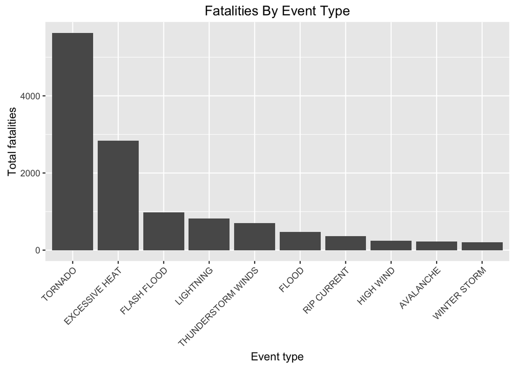

```r
library(ggplot2)
ggplot(data=top.fatalities, aes(x=event.type, y=fatality.total)) +
        geom_bar(stat="identity") + xlab("Event type") + ylab("Total fatalities") +
        ggtitle("Fatalities By Event Type") +
        theme(axis.text.x = element_text(angle = 45, hjust = 1))
```

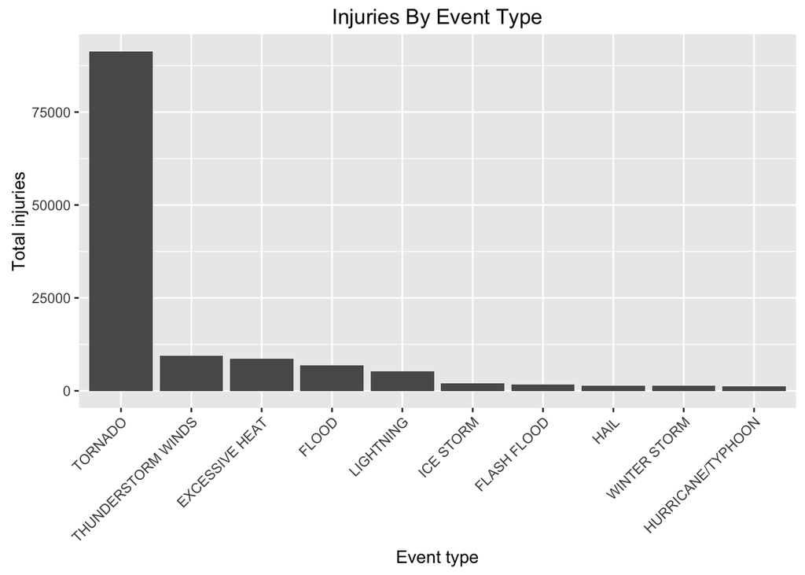

```r
ggplot(data=top.injuries, aes(x=event.type, y=injury.total)) +
        geom_bar(stat="identity") + xlab("Event type") + ylab("Total injuries") +
        ggtitle("Injuries By Event Type") +
        theme(axis.text.x = element_text(angle = 45, hjust = 1))
```

#### This analysis shows that the tornadoes are the most harmful events for people in the United States.

### Which types of events have the greatest economic consequences?

Let’s plot property damage caused for each events

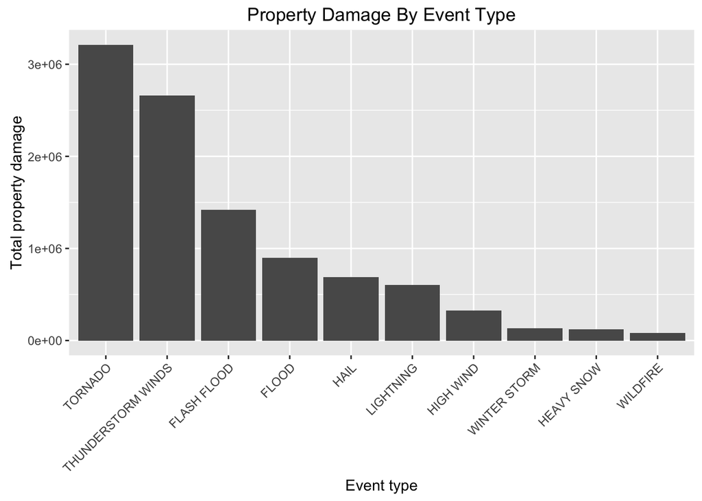

```r
ggplot(data=top.prop.dmg, aes(x=event.type, y=prop.dmg.total)) +
        geom_bar(stat="identity") + xlab("Event type") +
        ylab("Total property damage") +  ggtitle("Property Damage By Event Type") +
        theme(axis.text.x = element_text(angle = 45, hjust = 1))
```